# R Notebook

Problem1: Predicting number of college applications 1)Download the dataset college.csv and explore its overall structure. Get a summary statistics of each variable. Answer the following questions: • How many observations do you have in the data? • How many categorical and numeric variables you have in your data? • Is there any missing value?

```r
college = read.csv("C:/Users/prabh/Downloads/College.csv", stringsAsFactors = TRUE)
str(college)
```

```
'data.frame':   777 obs. of  19 variables:
 $ X          : Factor w/ 777 levels "Abilene Christian University",..: 1 2 3 4 5 6 7 8 9 10 ...
 $ Private    : Factor w/ 2 levels "No","Yes": 2 2 2 2 2 2 2 2 2 2 ...
 $ Apps       : int  1660 2186 1428 417 193 587 353 1899 1038 582 ...
 $ Accept     : int  1232 1924 1097 349 146 479 340 1720 839 498 ...
 $ Enroll     : int  721 512 336 137 55 158 103 489 227 172 ...
 $ Top10perc  : int  23 16 22 60 16 38 17 37 30 21 ...
 $ Top25perc  : int  52 29 50 89 44 62 45 68 63 44 ...
 $ F.Undergrad: int  2885 2683 1036 510 249 678 416 1594 973 799 ...
 $ P.Undergrad: int  537 1227 99 63 869 41 230 32 306 78 ...
 $ Outstate   : int  7440 12280 11250 12960 7560 13500 13290 13868 15595 10468 ...
 $ Room.Board : int  3300 6450 3750 5450 4120 3335 5720 4826 4400 3380 ...
 $ Books      : int  450 750 400 450 800 500 500 450 300 660 ...
 $ Personal   : int  2200 1500 1165 875 1500 675 1500 850 500 1800 ...
 $ PhD        : int  70 29 53 92 76 67 90 89 79 40 ...
 $ Terminal   : int  78 30 66 97 72 73 93 100 84 41 ...
 $ S.F.Ratio  : num  18.1 12.2 12.9 7.7 11.9 9.4 11.5 13.7 11.3 11.5 ...
 $ perc.alumni: int  12 16 30 37 2 11 26 37 23 15 ...
 $ Expend     : int  7041 10527 8735 19016 10922 9727 8861 11487 11644 8991 ...
 $ Grad.Rate  : int  60 56 54 59 15 55 63 73 80 52 ...
```

```r
summary(college)
```

```
                            X       Private        Apps           Accept
 Abilene Christian University:  1   No :212   Min.   :   81   Min.   :   72
 Adelphi University          :  1   Yes:565   1st Qu.:  776   1st Qu.:  604
 Adrian College              :  1             Median : 1558   Median : 1110
 Agnes Scott College         :  1             Mean   : 3002   Mean   : 2019
 Alaska Pacific University   :  1             3rd Qu.: 3624   3rd Qu.: 2424
 Albertson College           :  1             Max.   :48094   Max.   :26330
 (Other)                     :771
     Enroll       Top10perc       Top25perc      F.Undergrad     P.Undergrad
 Min.   :  35   Min.   : 1.00   Min.   :  9.0   Min.   :  139   Min.   :    1.0
 1st Qu.: 242   1st Qu.:15.00   1st Qu.: 41.0   1st Qu.:  992   1st Qu.:   95.0
 Median : 434   Median :23.00   Median : 54.0   Median : 1707   Median :  353.0
 Mean   : 780   Mean   :27.56   Mean   : 55.8   Mean   : 3700   Mean   :  855.3
 3rd Qu.: 902   3rd Qu.:35.00   3rd Qu.: 69.0   3rd Qu.: 4005   3rd Qu.:  967.0
 Max.   :6392   Max.   :96.00   Max.   :100.0   Max.   :31643   Max.   :21836.0

    Outstate       Room.Board       Books           Personal         PhD
 Min.   : 2340   Min.   :1780   Min.   :  96.0   Min.   : 250   Min.   :  8.00
 1st Qu.: 7320   1st Qu.:3597   1st Qu.: 470.0   1st Qu.: 850   1st Qu.: 62.00
 Median : 9990   Median :4200   Median : 500.0   Median :1200   Median : 75.00
 Mean   :10441   Mean   :4358   Mean   : 549.4   Mean   :1341   Mean   : 72.66
 3rd Qu.:12925   3rd Qu.:5050   3rd Qu.: 600.0   3rd Qu.:1700   3rd Qu.: 85.00
 Max.   :21700   Max.   :8124   Max.   :2340.0   Max.   :6800   Max.   :103.00

    Terminal       S.F.Ratio      perc.alumni        Expend        Grad.Rate
 Min.   : 24.0   Min.   : 2.50   Min.   : 0.00   Min.   : 3186   Min.   : 10.00
 1st Qu.: 71.0   1st Qu.:11.50   1st Qu.:13.00   1st Qu.: 6751   1st Qu.: 53.00
 Median : 82.0   Median :13.60   Median :21.00   Median : 8377   Median : 65.00
 Mean   : 79.7   Mean   :14.09   Mean   :22.74   Mean   : 9660   Mean   : 65.46
 3rd Qu.: 92.0   3rd Qu.:16.50   3rd Qu.:31.00   3rd Qu.:10830   3rd Qu.: 78.00
 Max.   :100.0   Max.   :39.80   Max.   :64.00   Max.   :56233   Max.   :118.00
```

```r
sapply(colnames(college), function(x) class(college[[x]]))
```

```
          X     Private        Apps      Accept      Enroll   Top10perc   Top25perc
   "factor"    "factor"   "integer"   "integer"   "integer"   "integer"   "integer"
F.Undergrad P.Undergrad    Outstate  Room.Board       Books    Personal         PhD
  "integer"   "integer"   "integer"   "integer"   "integer"   "integer"   "integer"
   Terminal   S.F.Ratio perc.alumni      Expend   Grad.Rate
  "integer"   "numeric"   "integer"   "integer"   "integer"
```

```r
which(is.na(college))
```

```
integer(0)
```

```r
colSums(is.na(college))
```

```
          X     Private        Apps      Accept      Enroll   Top10perc   Top25perc
          0           0           0           0           0           0           0
F.Undergrad P.Undergrad    Outstate  Room.Board       Books    Personal         PhD
          0           0           0           0           0           0           0
   Terminal   S.F.Ratio perc.alumni      Expend   Grad.Rate
          0           0           0           0           0
```

ans: There are 777 observations in the data There are 2 categorical and 17 numeric variables in the data. There are no missing values in the data.

2)Removing the first column (the name of the college)

```r
college <- college[-1]
str(college)
```

```
'data.frame':   777 obs. of  18 variables:
 $ Private    : Factor w/ 2 levels "No","Yes": 2 2 2 2 2 2 2 2 2 2 ...
 $ Apps       : int  1660 2186 1428 417 193 587 353 1899 1038 582 ...
 $ Accept     : int  1232 1924 1097 349 146 479 340 1720 839 498 ...
 $ Enroll     : int  721 512 336 137 55 158 103 489 227 172 ...
 $ Top10perc  : int  23 16 22 60 16 38 17 37 30 21 ...
 $ Top25perc  : int  52 29 50 89 44 62 45 68 63 44 ...
 $ F.Undergrad: int  2885 2683 1036 510 249 678 416 1594 973 799 ...
 $ P.Undergrad: int  537 1227 99 63 869 41 230 32 306 78 ...
 $ Outstate   : int  7440 12280 11250 12960 7560 13500 13290 13868 15595 10468 ...
 $ Room.Board : int  3300 6450 3750 5450 4120 3335 5720 4826 4400 3380 ...
 $ Books      : int  450 750 400 450 800 500 500 450 300 660 ...
 $ Personal   : int  2200 1500 1165 875 1500 675 1500 850 500 1800 ...
 $ PhD        : int  70 29 53 92 76 67 90 89 79 40 ...
 $ Terminal   : int  78 30 66 97 72 73 93 100 84 41 ...
 $ S.F.Ratio  : num  18.1 12.2 12.9 7.7 11.9 9.4 11.5 13.7 11.3 11.5 ...
 $ perc.alumni: int  12 16 30 37 2 11 26 37 23 15 ...
 $ Expend     : int  7041 10527 8735 19016 10922 9727 8861 11487 11644 8991 ...
 $ Grad.Rate  : int  60 56 54 59 15 55 63 73 80 52 ...
```

3)Which variables are associated with “Apps”? Use appropriate plots and statistics test to answer this question.

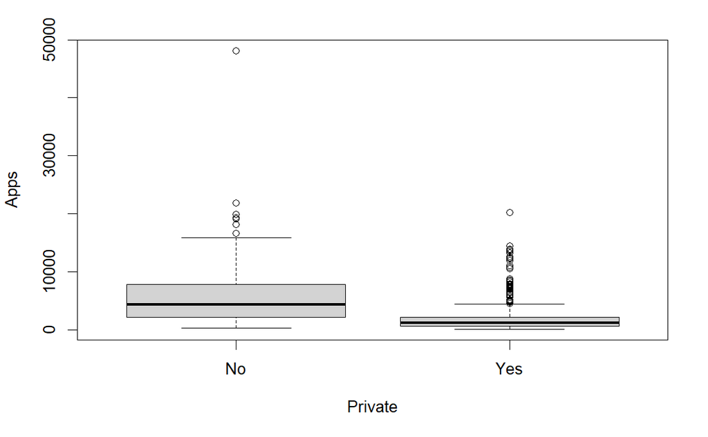

```r
attach(college)
plot(Apps~Private)
```

```r
t.test(Apps~Private)
```

```
    Welch Two Sample t-test

data:  Apps by Private
t = 9.7985, df = 244.49, p-value < 2.2e-16
alternative hypothesis: true difference in means between group No and group Yes is not equal to 0
95 percent confidence interval:
 2997.758 4506.223
sample estimates:
 mean in group No mean in group Yes
         5729.920          1977.929
```

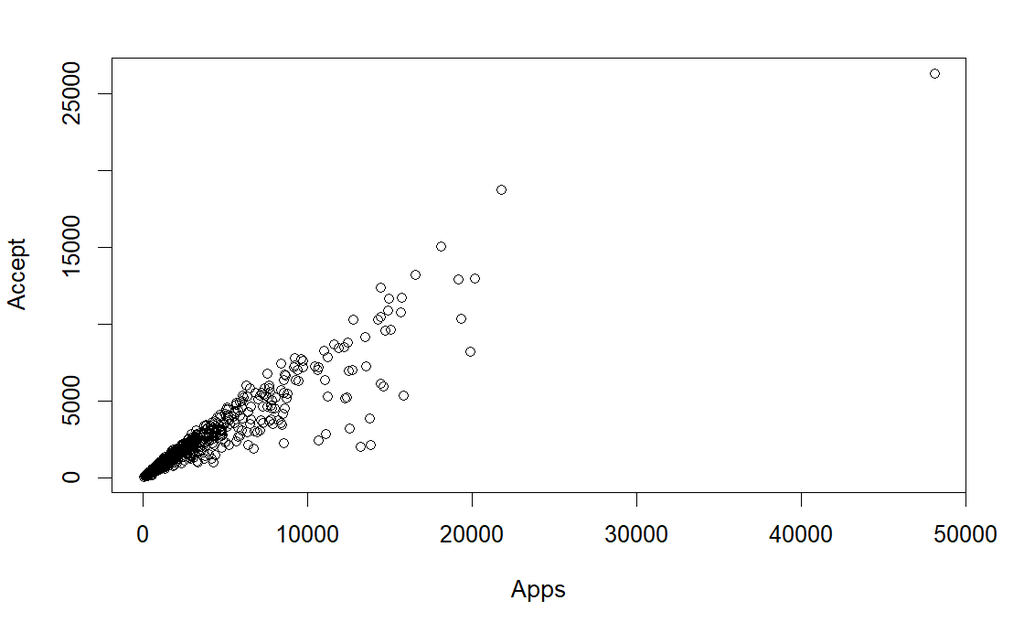

```r
plot(x = Apps, y = Accept)
```

```r
cor.test(Apps, Accept)
```

```
    Pearson's product-moment correlation

data:  Apps and Accept
t = 79.226, df = 775, p-value < 2.2e-16
alternative hypothesis: true correlation is not equal to 0
95 percent confidence interval:
 0.9351715 0.9506993
sample estimates:
      cor
0.9434506
```

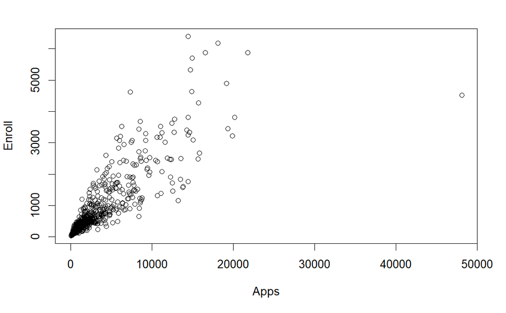

```r
plot(x = Apps, y = Enroll)
```

```r
cor.test(Apps, Enroll)
```

```
    Pearson's product-moment correlation

data:  Apps and Enroll
t = 44.323, df = 775, p-value < 2.2e-16
alternative hypothesis: true correlation is not equal to 0
95 percent confidence interval:
 0.8256652 0.8656003
sample estimates:
      cor
0.8468221
```

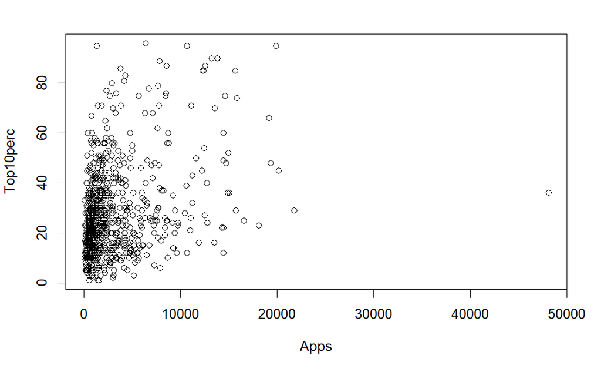

```r
plot(x = Apps, y = Top10perc)
```

```r
cor.test(Apps, Top10perc)
```

```
    Pearson's product-moment correlation

data:  Apps and Top10perc
t = 10.026, df = 775, p-value < 2.2e-16
alternative hypothesis: true correlation is not equal to 0
95 percent confidence interval:
 0.2750555 0.3996428
sample estimates:
      cor
0.3388337
```

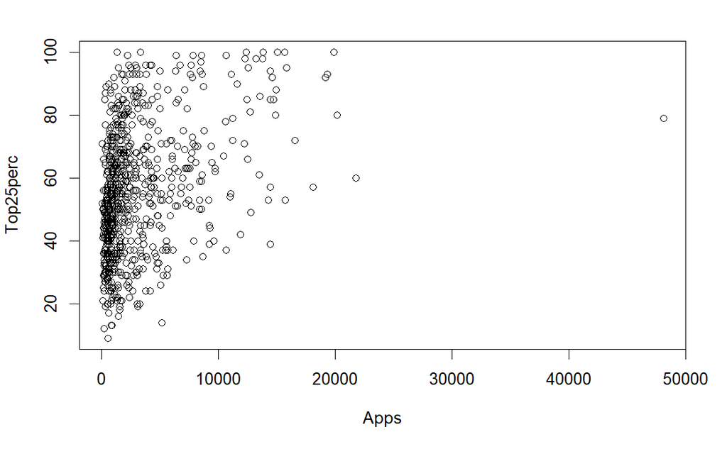

```r
plot(x = Apps, y = Top25perc)
```

```r
cor.test(Apps, Top25perc)
```

```
    Pearson's product-moment correlation

data:  Apps and Top25perc
t = 10.457, df = 775, p-value < 2.2e-16
alternative hypothesis: true correlation is not equal to 0
95 percent confidence interval:
 0.2884405 0.4117887
sample estimates:
      cor
0.3516399
```

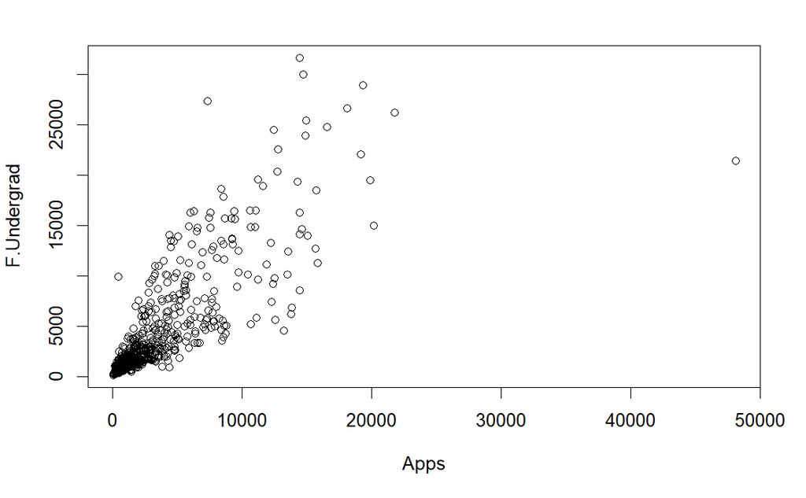

```r
plot(x = Apps, y = F.Undergrad)
```

```r
cor.test(Apps, F.Undergrad)
```

```
    Pearson's product-moment correlation

data:  Apps and F.Undergrad
t = 39.082, df = 775, p-value < 2.2e-16
alternative hypothesis: true correlation is not equal to 0
95 percent confidence interval:
 0.7893775 0.8368823
sample estimates:
      cor
0.8144906
```

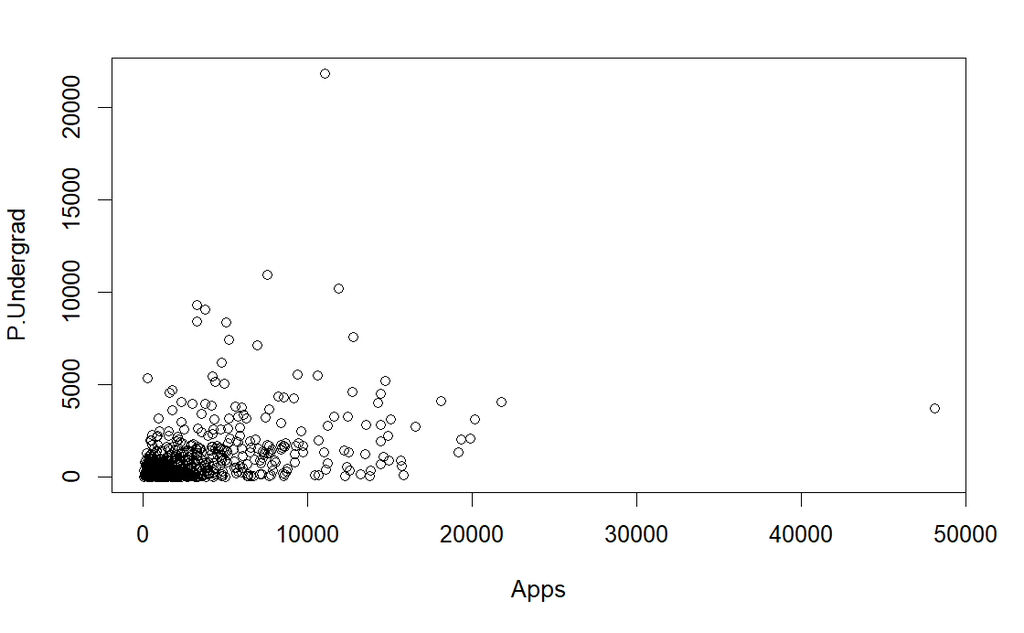

```r
plot(x = Apps, y = P.Undergrad)
```

```r
cor.test(Apps, P.Undergrad)
```

```
    Pearson's product-moment correlation

data:  Apps and P.Undergrad
t = 12.087, df = 775, p-value < 2.2e-16
alternative hypothesis: true correlation is not equal to 0
95 percent confidence interval:
 0.3373816 0.4558291
sample estimates:
      cor
0.3982643
```

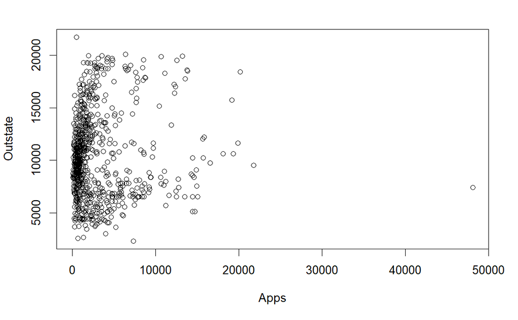

```r
plot(x = Apps, y = Outstate)
```

```r
cor.test(Apps, Outstate)
```

```
    Pearson's product-moment correlation

data:  Apps and Outstate
t = 1.3981, df = 775, p-value = 0.1625
alternative hypothesis: true correlation is not equal to 0
95 percent confidence interval:
 -0.02024552  0.12006858
sample estimates:
       cor
0.05015903
```

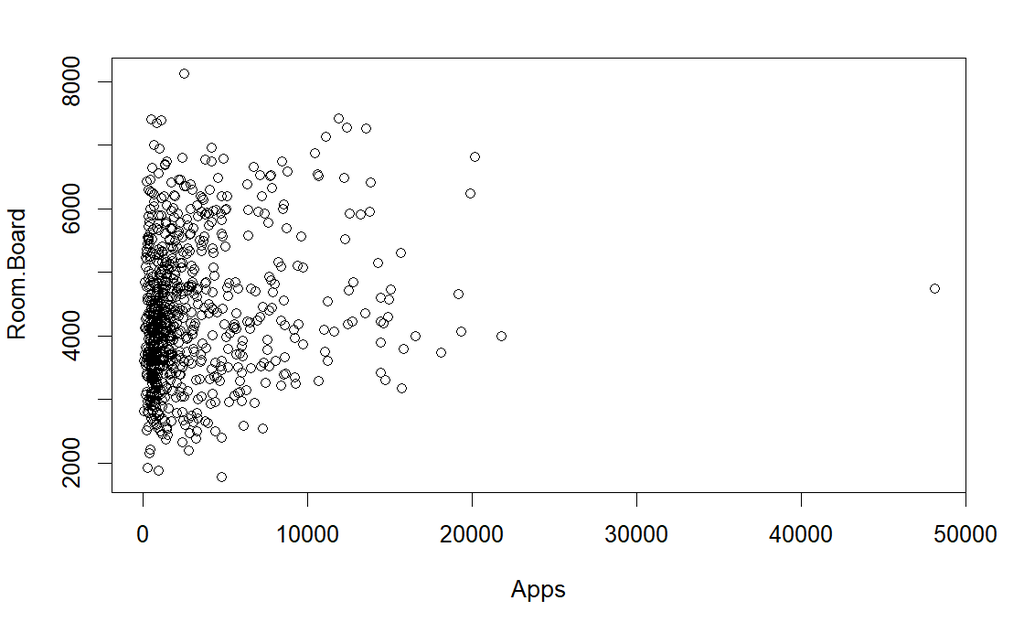

```r
plot(x = Apps, y = Room.Board)
```

```r
cor.test(Apps, Room.Board)
```

```
    Pearson's product-moment correlation

data:  Apps and Room.Board
t = 4.6555, df = 775, p-value = 3.802e-06
alternative hypothesis: true correlation is not equal to 0
95 percent confidence interval:
 0.0957162 0.2325741
sample estimates:
     cor
0.164939
```

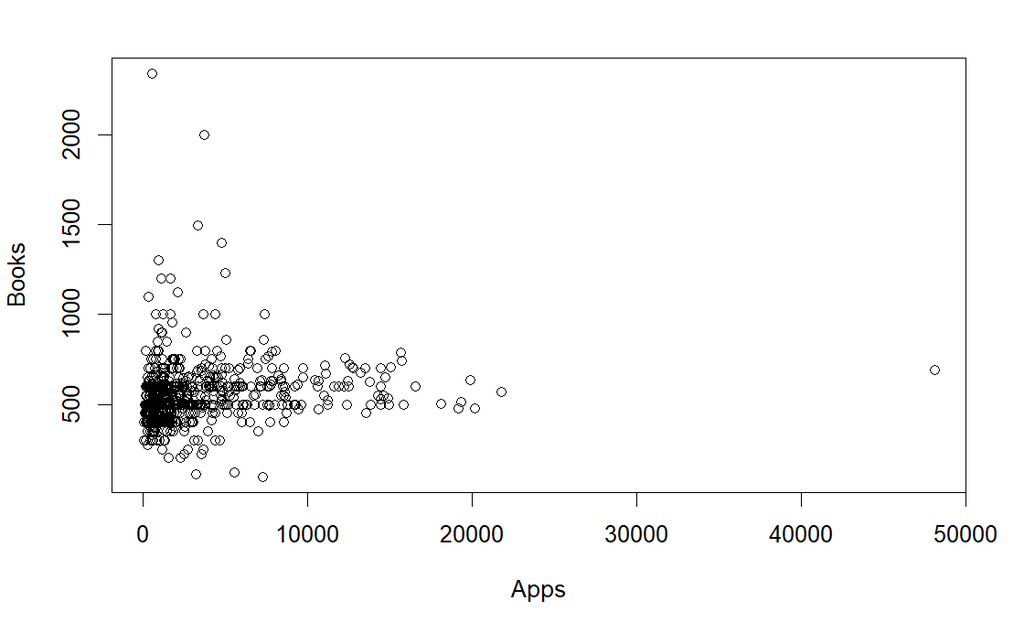

```r
plot(x = Apps, y = Books)
```

```r
cor.test(Apps, Books)
```

```
    Pearson's product-moment correlation

data:  Apps and Books
t = 3.7231, df = 775, p-value = 0.000211
alternative hypothesis: true correlation is not equal to 0
95 percent confidence interval:
 0.06281107 0.20101759
sample estimates:
      cor
0.1325586
```

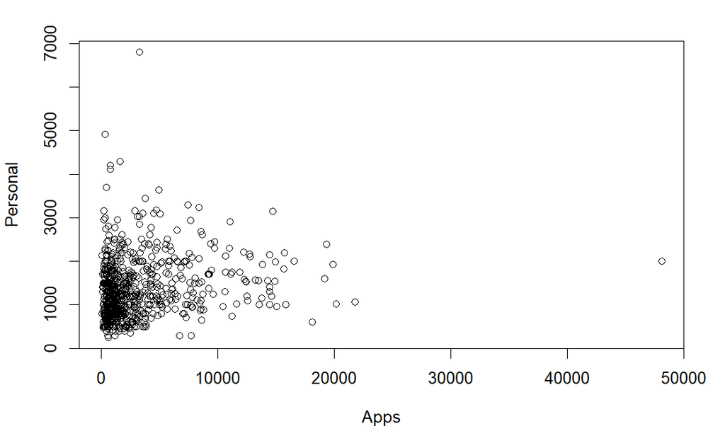

```r
plot(x = Apps, y = Personal)
```

```r
cor.test(Apps, Personal)
```

```
    Pearson's product-moment correlation

data:  Apps and Personal
t = 5.0571, df = 775, p-value = 5.318e-07
alternative hypothesis: true correlation is not equal to 0
95 percent confidence interval:
 0.1097777 0.2459719
sample estimates:
      cor
0.1787308
```

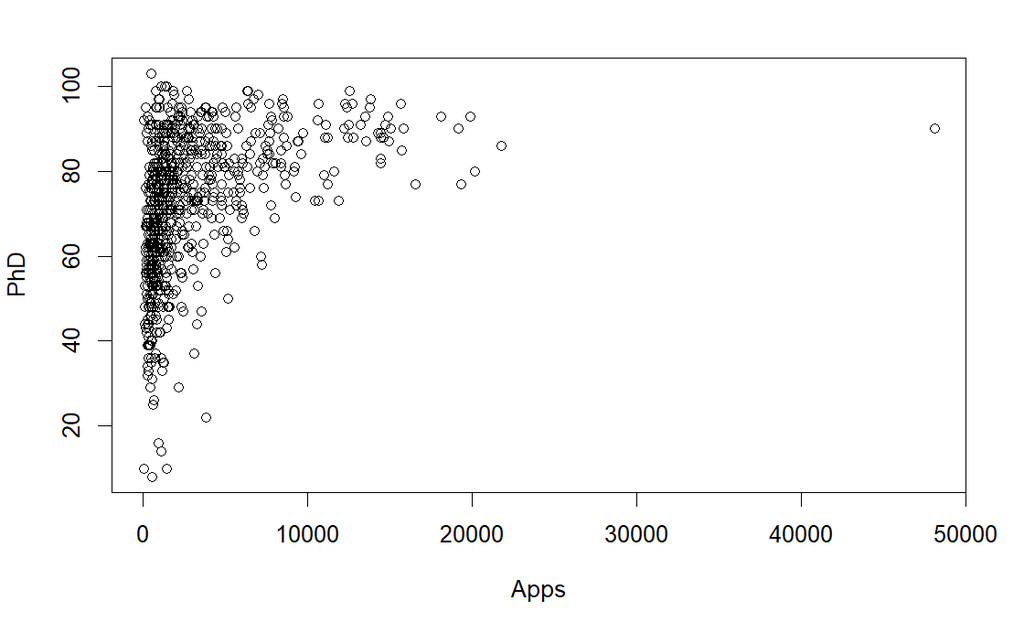

```r
plot(x = Apps, y = PhD)
```

```r
cor.test(Apps, PhD)
```

```
    Pearson's product-moment correlation

data:  Apps and PhD
t = 11.816, df = 775, p-value < 2.2e-16
alternative hypothesis: true correlation is not equal to 0
95 percent confidence interval:
 0.3294162 0.4487006
sample estimates:
      cor
0.3906973
```

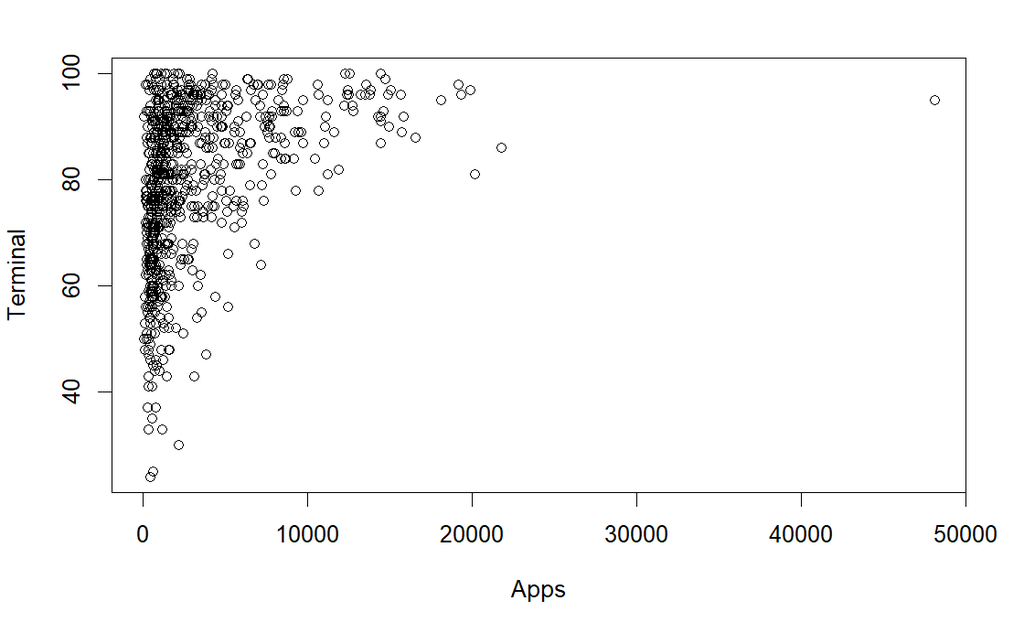

```r
plot(x = Apps, y = Terminal)
```

```r
cor.test(Apps, Terminal)
```

```
    Pearson's product-moment correlation

data:  Apps and Terminal
t = 11.07, df = 775, p-value < 2.2e-16
alternative hypothesis: true correlation is not equal to 0
95 percent confidence interval:
 0.3071401 0.4286842
sample estimates:
      cor
0.3694915
```

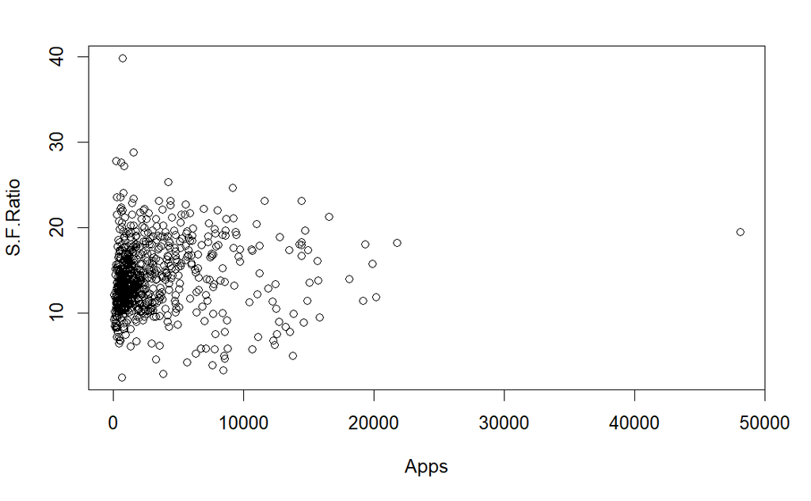

```r
plot(x = Apps, y = S.F.Ratio)
```

```r
cor.test(Apps, S.F.Ratio)
```

```
    Pearson's product-moment correlation

data:  Apps and S.F.Ratio
t = 2.6746, df = 775, p-value = 0.00764
alternative hypothesis: true correlation is not equal to 0
95 percent confidence interval:
 0.02547122 0.16485730
sample estimates:
       cor
0.09563303
```

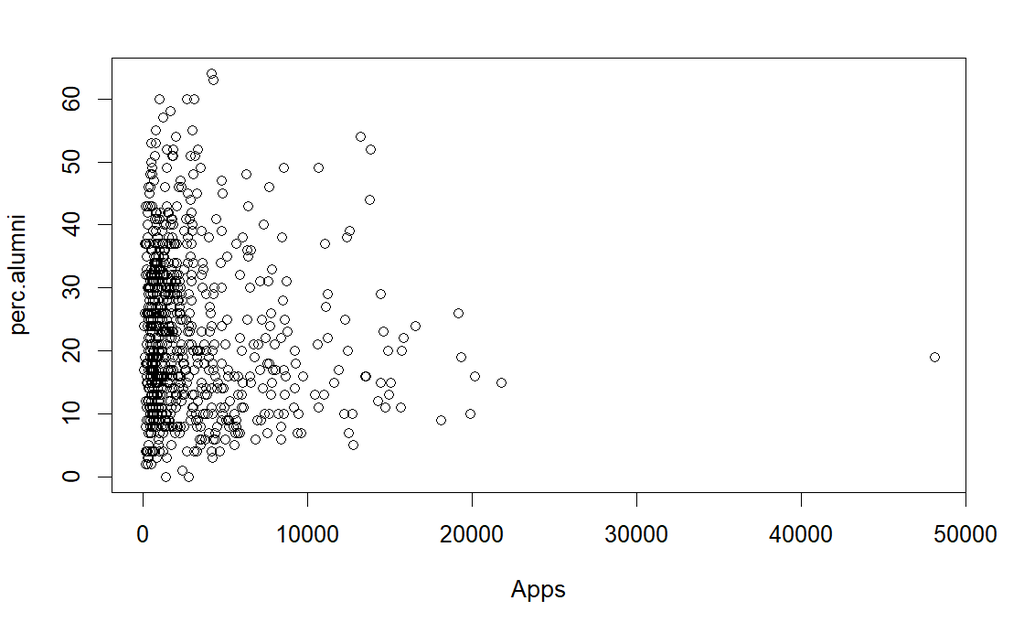

```r
plot(x = Apps, y = perc.alumni)
```

```r
cor.test(Apps, perc.alumni)
```

```
    Pearson's product-moment correlation

data:  Apps and perc.alumni
t = -2.5221, df = 775, p-value = 0.01187
alternative hypothesis: true correlation is not equal to 0
95 percent confidence interval:
 -0.1595466 -0.0200198
sample estimates:
        cor
-0.09022589
```

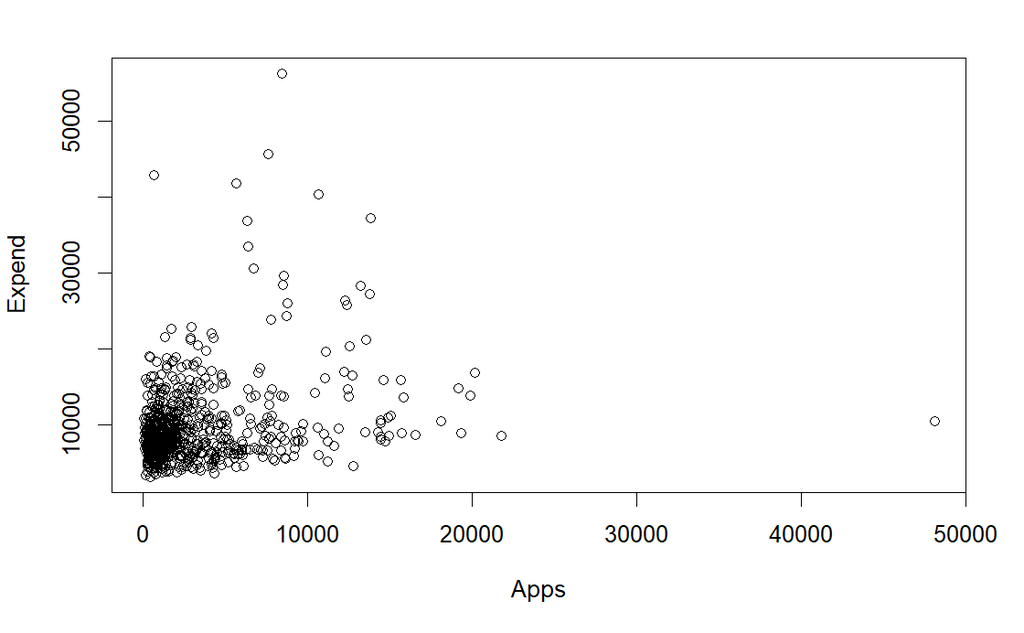

```r
plot(x = Apps, y = Expend)
```

```r
cor.test(Apps, Expend)
```

```
    Pearson's product-moment correlation

data:  Apps and Expend
t = 7.4833, df = 775, p-value = 1.971e-13
alternative hypothesis: true correlation is not equal to 0
95 percent confidence interval:
 0.1927786 0.3240094
sample estimates:
     cor
0.259592
```

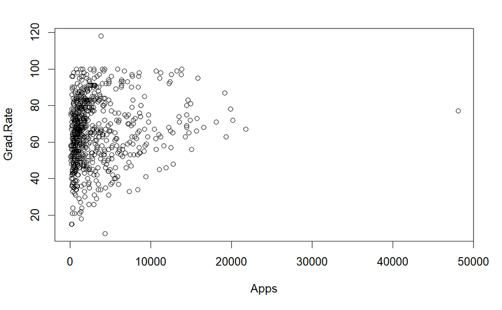

```r
plot(x = Apps, y = Grad.Rate)
```

```r
cor.test(Apps, Grad.Rate)
```

```
    Pearson's product-moment correlation

data:  Apps and Grad.Rate
t = 4.1302, df = 775, p-value = 4.019e-05
alternative hypothesis: true correlation is not equal to 0
95 percent confidence interval:
 0.07721849 0.21486991
sample estimates:
      cor
0.1467546
```

4)Remove variables not associated with “Apps”

```r
college <- college[c(-9,-16)]
str(college)
```

```
'data.frame':   777 obs. of  16 variables:
 $ Private    : Factor w/ 2 levels "No","Yes": 2 2 2 2 2 2 2 2 2 2 ...
 $ Apps       : int  1660 2186 1428 417 193 587 353 1899 1038 582 ...
 $ Accept     : int  1232 1924 1097 349 146 479 340 1720 839 498 ...
 $ Enroll     : int  721 512 336 137 55 158 103 489 227 172 ...
 $ Top10perc  : int  23 16 22 60 16 38 17 37 30 21 ...
 $ Top25perc  : int  52 29 50 89 44 62 45 68 63 44 ...
 $ F.Undergrad: int  2885 2683 1036 510 249 678 416 1594 973 799 ...
 $ P.Undergrad: int  537 1227 99 63 869 41 230 32 306 78 ...
 $ Room.Board : int  3300 6450 3750 5450 4120 3335 5720 4826 4400 3380 ...
 $ Books      : int  450 750 400 450 800 500 500 450 300 660 ...
 $ Personal   : int  2200 1500 1165 875 1500 675 1500 850 500 1800 ...
 $ PhD        : int  70 29 53 92 76 67 90 89 79 40 ...
 $ Terminal   : int  78 30 66 97 72 73 93 100 84 41 ...
 $ S.F.Ratio  : num  18.1 12.2 12.9 7.7 11.9 9.4 11.5 13.7 11.3 11.5 ...
 $ Expend     : int  7041 10527 8735 19016 10922 9727 8861 11487 11644 8991 ...
 $ Grad.Rate  : int  60 56 54 59 15 55 63 73 80 52 ...
```

5)plot the histogram of the number of applications “Apps” variable. Explain what the histogram shows?

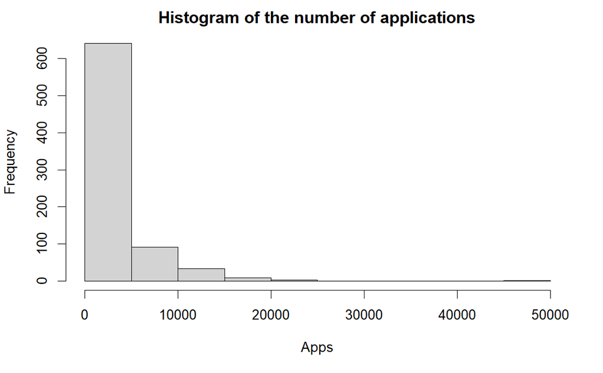

```r
hist(college$Apps, main = "Histogram of the number of applications", xlab = "Apps")
```

6)Split the data into train and test

```r
college_train<-college[1:621, ]
college_test<-college[622:777, ]
```

7)set the random seed

```r
set.seed(123)
```

8)Use caret package to run 10 fold cross validation using linear regression method on the train data . Print the resulting model to see the cross validation RMSE. In addition, take a summary of the model and interpret the coefficients. Which coefficients are statistically different from zero? What does this meant?

9)Compute RMSE of the model on the test data. You can call “predict” function and pass to it the model (returned by caret train method) and the test data. Then compute RMSE of the predictions returned by the “predict” method.

10. Set the random seed again. We need to do this before each training to ensure we get the same folds in cross validation. Set.seed(123) so we can compare the models using their cross validation RMSE.

```r
library(caret)
tr.control1 = trainControl(method="cv", number = 10)

college.lm=lm(Apps~.,data =college)
summary(college.lm)
```

```
Call:
lm(formula = Apps ~ ., data = college)

Residuals:
    Min      1Q  Median      3Q     Max
-4925.0  -442.3   -37.4   320.5  8389.6

Coefficients:
              Estimate Std. Error t value Pr(>|t|)
(Intercept) -327.45126  412.23239  -0.794  0.42725
PrivateYes  -726.54492  129.08754  -5.628 2.56e-08 ***
Accept         1.56134    0.04035  38.695  < 2e-16 ***
Enroll        -0.87077    0.18739  -4.647 3.97e-06 ***
Top10perc     48.60136    5.63850   8.620  < 2e-16 ***
Top25perc    -14.54468    4.52461  -3.215  0.00136 **
F.Undergrad    0.06892    0.03300   2.089  0.03706 *
P.Undergrad    0.04531    0.03253   1.393  0.16410
Room.Board     0.08106    0.04580   1.770  0.07715 .
Books          0.07282    0.24087   0.302  0.76249
Personal       0.05871    0.06323   0.929  0.35342
PhD           -9.90155    4.68783  -2.112  0.03500 *
Terminal      -6.04491    5.10652  -1.184  0.23688
S.F.Ratio     20.81008   13.08608   1.590  0.11219
Expend         0.06156    0.01197   5.144 3.42e-07 ***
Grad.Rate      6.17660    2.87010   2.152  0.03171 *
---
Signif. codes:  0 ‘***’ 0.001 ‘**’ 0.01 ‘*’ 0.05 ‘.’ 0.1 ‘ ’ 1

Residual standard error: 1054 on 761 degrees of freedom
Multiple R-squared:  0.9272,    Adjusted R-squared:  0.9258
F-statistic: 646.4 on 15 and 761 DF,  p-value: < 2.2e-16
```

```r
set.seed(123)

college.cv.lm=train(Apps~., method="lm", data=college_train, trControl=tr.control1)
college.cv.lm
```

```
Linear Regression

621 samples
 15 predictor

No pre-processing
Resampling: Cross-Validated (10 fold)
Summary of sample sizes: 559, 558, 558, 560, 558, 559, ...
Resampling results:

  RMSE     Rsquared   MAE
  1097.98  0.9144707  618.7578

Tuning parameter 'intercept' was held constant at a value of TRUE
```

```r
summary(college.cv.lm)
```

```
Call:
lm(formula = .outcome ~ ., data = dat)

Residuals:
    Min      1Q  Median      3Q     Max
-5293.6  -403.3   -27.5   311.9  7435.2

Coefficients:
              Estimate Std. Error t value Pr(>|t|)
(Intercept) -514.00720  454.07274  -1.132   0.2581
PrivateYes  -758.42312  148.14845  -5.119 4.13e-07 ***
Accept         1.65876    0.04422  37.511  < 2e-16 ***
Enroll        -1.15859    0.20703  -5.596 3.32e-08 ***
Top10perc     43.06548    6.21044   6.934 1.05e-11 ***
Top25perc    -12.04320    4.99617  -2.410   0.0162 *
F.Undergrad    0.07653    0.03649   2.097   0.0364 *
P.Undergrad    0.02660    0.04902   0.543   0.5876
Room.Board     0.08118    0.05051   1.607   0.1086
Books          0.12409    0.26143   0.475   0.6352
Personal       0.08157    0.07147   1.141   0.2542
PhD           -9.66169    5.08486  -1.900   0.0579 .
Terminal      -5.04079    5.50608  -0.915   0.3603
S.F.Ratio     32.50027   14.72900   2.207   0.0277 *
Expend         0.07480    0.01389   5.385 1.04e-07 ***
Grad.Rate      3.47841    3.12133   1.114   0.2656
---
Signif. codes:  0 ‘***’ 0.001 ‘**’ 0.01 ‘*’ 0.05 ‘.’ 0.1 ‘ ’ 1

Residual standard error: 1046 on 605 degrees of freedom
Multiple R-squared:  0.9257,    Adjusted R-squared:  0.9238
F-statistic: 502.4 on 15 and 605 DF,  p-value: < 2.2e-16
```

```r
predictions= predict(college.cv.lm, college_test)

rmse=function(predictions, truevalues)
  return(sqrt(mean((predictions-truevalues)^2)))

mae=function(predictions, truevalues)
  return(mean(abs(predictions-truevalues)))

mape=function(predictions, truevalues)
  return(mean(abs(predictions-truevalues)/truevalues))

print("rmse:")
```

```
[1] "rmse:"
```

```r
rmse(predictions, college_test$Apps)
```

```
[1] 1125.921
```

```r
print("mae:")
```

```
[1] "mae:"
```

```r
mae(predictions, college_test$Apps)
```

```
[1] 716.2272
```

```r
print("mape:")
```

```
[1] "mape:"
```

```r
mape(predictions, college_test$Apps)
```

```
[1] 0.2884428
```

```r
RMSE(predictions, college_test$Apps)
```

```
[1] 1125.921
```

11)Use caret and leap packages to run a 10 fold cross validation using step wise linear regression method with backward selection on the train data. The train method by default uses maximum of 4 predictors and reports the best models with 1..4 predictors. We need to change this parameter to consider all predictors. So inside your train function, add the following parameter tuneGrid = data.frame(nvmax = 1:n), where n is the number of variables you use to predict “Apps” . Which model (with how many variables or nvmax ) has the lowest cross validation RMSE? Take the summary of the final model, which variables are selected in the model with the lowest RMSE?

```r
library(leaps)
library(caret)
train.control=trainControl(method = "cv", number = 10)
step.model<-train(Apps~., data = college,method= "leapBackward",trControl= train.control, tuneGrid = data.frame(nvmax = 1:16))
summary(step.model)
```

```
Subset selection object
15 Variables  (and intercept)
            Forced in Forced out
PrivateYes      FALSE      FALSE
Accept          FALSE      FALSE
Enroll          FALSE      FALSE
Top10perc       FALSE      FALSE
Top25perc       FALSE      FALSE
F.Undergrad     FALSE      FALSE
P.Undergrad     FALSE      FALSE
Room.Board      FALSE      FALSE
Books           FALSE      FALSE
Personal        FALSE      FALSE
PhD             FALSE      FALSE
Terminal        FALSE      FALSE
S.F.Ratio       FALSE      FALSE
Expend          FALSE      FALSE
Grad.Rate       FALSE      FALSE
1 subsets of each size up to 6
Selection Algorithm: backward
         PrivateYes Accept Enroll Top10perc Top25perc F.Undergrad P.Undergrad
1  ( 1 ) " "        "*"    " "    " "       " "       " "         " "
2  ( 1 ) " "        "*"    " "    "*"       " "       " "         " "
3  ( 1 ) " "        "*"    " "    "*"       " "       " "         " "
4  ( 1 ) "*"        "*"    " "    "*"       " "       " "         " "
5  ( 1 ) "*"        "*"    "*"    "*"       " "       " "         " "
6  ( 1 ) "*"        "*"    "*"    "*"       " "       " "         " "
         Room.Board Books Personal PhD Terminal S.F.Ratio Expend Grad.Rate
1  ( 1 ) " "        " "   " "      " " " "      " "       " "    " "
2  ( 1 ) " "        " "   " "      " " " "      " "       " "    " "
3  ( 1 ) " "        " "   " "      " " " "      " "       "*"    " "
4  ( 1 ) " "        " "   " "      " " " "      " "       "*"    " "
5  ( 1 ) " "        " "   " "      " " " "      " "       "*"    " "
6  ( 1 ) " "        " "   " "      "*" " "      " "       "*"    " "
```

```r
print(step.model)
```

```
Linear Regression with Backwards Selection

777 samples
 15 predictor

No pre-processing
Resampling: Cross-Validated (10 fold)
Summary of sample sizes: 700, 700, 699, 700, 699, 699, ...
Resampling results across tuning parameters:

  nvmax  RMSE      Rsquared   MAE
   1     1253.366  0.8873591  607.5546
   2     1110.476  0.9126851  652.3743
   3     1127.409  0.9089860  654.3220
   4     1126.176  0.9109887  655.6197
   5     1111.345  0.9127585  654.6418
   6     1093.578  0.9145303  644.0174
   7     1109.066  0.9130358  645.5731
   8     1103.649  0.9133015  647.1211
   9     1099.146  0.9140786  647.3582
  10     1105.702  0.9132288  651.3411
  11     1103.231  0.9137482  647.0949
  12     1102.674  0.9136999  645.9916
  13     1105.081  0.9134781  647.8857
  14     1102.716  0.9139653  646.4839
  15     1103.608  0.9137851  646.5657
  16     1103.608  0.9137851  646.5657

RMSE was used to select the optimal model using the smallest value.
The final value used for the model was nvmax = 6.
```

ans:The model with 6 variables or nvmax = 6 has the lowest cross validation RMSE of 1093.578 The variables- Accept, Top10perc, Expend, PrivateYes, Enroll, PhD are selected in the model with the lowest RMSE

12)Compute the RMSE of the stepwise model on the test data.

```r
predictions_n= predict(step.model, college_test)
RMSE(predictions_n, college_test$Apps)
```

```
[1] 1086.565
```

13)use “rpart” function to create a regression tree model from the train data. Get the predictions on test data and compute the RMSE.

```r
library(rpart)
c.rpart<-rpart(Apps ~ ., data = college_train)
p.c.rpart<-predict(c.rpart, college_test)
sqrt(mean((college_test$Apps-p.c.rpart)^2))
```

```
[1] 1441.396
```

14)Compare the RMSE on the test data for linear regression, stepwise regression, and the regression tree.

ans: RMSE on the test data for linear regression= 1125.921 RMSE on the test data for stepwise regression= 1086.565 RMSE on the test data for regression tree= 1441.396

The stepwise regression model has given the lowest RMSE(1086.565) on the test data among other two models.

The regression tree model has given the highest RMSE(1441.396) on the test data among other two models.

Problem2—Predicting Customer Churn using Logistic Regression and Decision Trees

1)Load the dataset. Examine its structure and remove the first three variables (RowNumber,CustomerId, and Surname). These variables are unique for each sample hence, they are not useful for prediction. Convert all string variables to factors.

```r
cm = read.csv("C:/Users/prabh/Downloads/Churn_Modelling.csv", stringsAsFactors = TRUE)
str(cm)
```

```
'data.frame':   10000 obs. of  14 variables:
 $ RowNumber      : int  1 2 3 4 5 6 7 8 9 10 ...
 $ CustomerId     : int  15634602 15647311 15619304 15701354 15737888 15574012 15592531 15656148 15792365 15592389 ...
 $ Surname        : Factor w/ 2932 levels "Abazu","Abbie",..: 1116 1178 2041 290 1823 538 178 2001 1147 1082 ...
 $ CreditScore    : int  619 608 502 699 850 645 822 376 501 684 ...
 $ Geography      : Factor w/ 3 levels "France","Germany",..: 1 3 1 1 3 3 1 2 1 1 ...
 $ Gender         : Factor w/ 2 levels "Female","Male": 1 1 1 1 1 2 2 1 2 2 ...
 $ Age            : int  42 41 42 39 43 44 50 29 44 27 ...
 $ Tenure         : int  2 1 8 1 2 8 7 4 4 2 ...
 $ Balance        : num  0 83808 159661 0 125511 ...
 $ NumOfProducts  : int  1 1 3 2 1 2 2 4 2 1 ...
 $ HasCrCard      : int  1 0 1 0 1 1 1 1 0 1 ...
 $ IsActiveMember : int  1 1 0 0 1 0 1 0 1 1 ...
 $ EstimatedSalary: num  101349 112543 113932 93827 79084 ...
 $ Exited         : int  1 0 1 0 0 1 0 1 0 0 ...
```

```r
summary(cm)
```

```
   RowNumber       CustomerId           Surname      CreditScore      Geography
 Min.   :    1   Min.   :15565701   Smith   :  32   Min.   :350.0   France :5014
 1st Qu.: 2501   1st Qu.:15628528   Martin  :  29   1st Qu.:584.0   Germany:2509
 Median : 5000   Median :15690738   Scott   :  29   Median :652.0   Spain  :2477
 Mean   : 5000   Mean   :15690941   Walker  :  28   Mean   :650.5
 3rd Qu.: 7500   3rd Qu.:15753234   Brown   :  26   3rd Qu.:718.0
 Max.   :10000   Max.   :15815690   Genovese:  25   Max.   :850.0
                                    (Other) :9831
    Gender          Age            Tenure          Balance       NumOfProducts
 Female:4543   Min.   :18.00   Min.   : 0.000   Min.   :     0   Min.   :1.00
 Male  :5457   1st Qu.:32.00   1st Qu.: 3.000   1st Qu.:     0   1st Qu.:1.00
               Median :37.00   Median : 5.000   Median : 97199   Median :1.00
               Mean   :38.92   Mean   : 5.013   Mean   : 76486   Mean   :1.53
               3rd Qu.:44.00   3rd Qu.: 7.000   3rd Qu.:127644   3rd Qu.:2.00
               Max.   :92.00   Max.   :10.000   Max.   :250898   Max.   :4.00

   HasCrCard      IsActiveMember   EstimatedSalary         Exited
 Min.   :0.0000   Min.   :0.0000   Min.   :    11.58   Min.   :0.0000
 1st Qu.:0.0000   1st Qu.:0.0000   1st Qu.: 51002.11   1st Qu.:0.0000
 Median :1.0000   Median :1.0000   Median :100193.91   Median :0.0000
 Mean   :0.7055   Mean   :0.5151   Mean   :100090.24   Mean   :0.2037
 3rd Qu.:1.0000   3rd Qu.:1.0000   3rd Qu.:149388.25   3rd Qu.:0.0000
 Max.   :1.0000   Max.   :1.0000   Max.   :199992.48   Max.   :1.0000
```

```r
which(is.na(cm))
```

```
integer(0)
```

```r
colSums(is.na(cm))
```

```
      RowNumber      CustomerId         Surname     CreditScore       Geography
              0               0               0               0               0
         Gender             Age          Tenure         Balance   NumOfProducts
              0               0               0               0               0
      HasCrCard  IsActiveMember EstimatedSalary          Exited
              0               0               0               0
```

```r
cm <- cm[-c(1,2,3)]
str(cm)
```

```
'data.frame':   10000 obs. of  11 variables:
 $ CreditScore    : int  619 608 502 699 850 645 822 376 501 684 ...
 $ Geography      : Factor w/ 3 levels "France","Germany",..: 1 3 1 1 3 3 1 2 1 1 ...
 $ Gender         : Factor w/ 2 levels "Female","Male": 1 1 1 1 1 2 2 1 2 2 ...
 $ Age            : int  42 41 42 39 43 44 50 29 44 27 ...
 $ Tenure         : int  2 1 8 1 2 8 7 4 4 2 ...
 $ Balance        : num  0 83808 159661 0 125511 ...
 $ NumOfProducts  : int  1 1 3 2 1 2 2 4 2 1 ...
 $ HasCrCard      : int  1 0 1 0 1 1 1 1 0 1 ...
 $ IsActiveMember : int  1 1 0 0 1 0 1 0 1 1 ...
 $ EstimatedSalary: num  101349 112543 113932 93827 79084 ...
 $ Exited         : int  1 0 1 0 0 1 0 1 0 0 ...
```

2)Use appropriate plots and statistical tests to find which variables are associated with “Exited”. Remove variables not associated with “Exited”

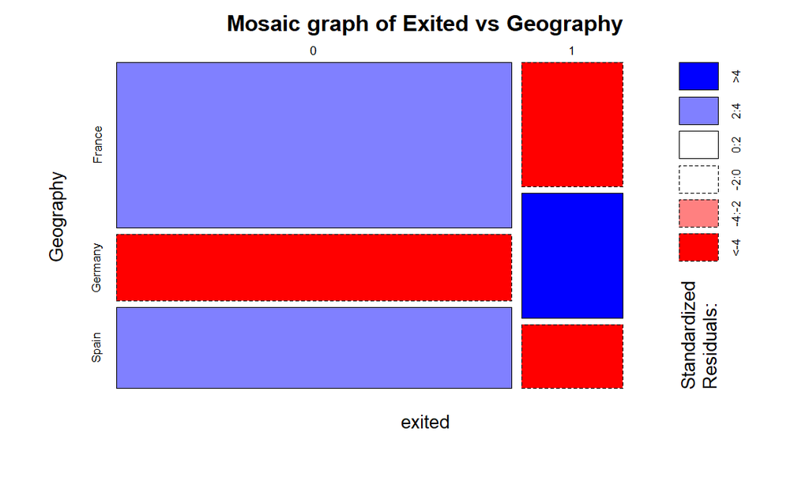

```r
attach(cm)
mytable1 <- table(Exited, Geography)
mosaicplot(mytable1, ylab= "Geography", xlab="exited", main = "Mosaic graph of Exited vs Geography", shade=TRUE)
```

```r
chisq.test(mytable1)
```

```
    Pearson's Chi-squared test

data:  mytable1
X-squared = 301.26, df = 2, p-value < 2.2e-16
```

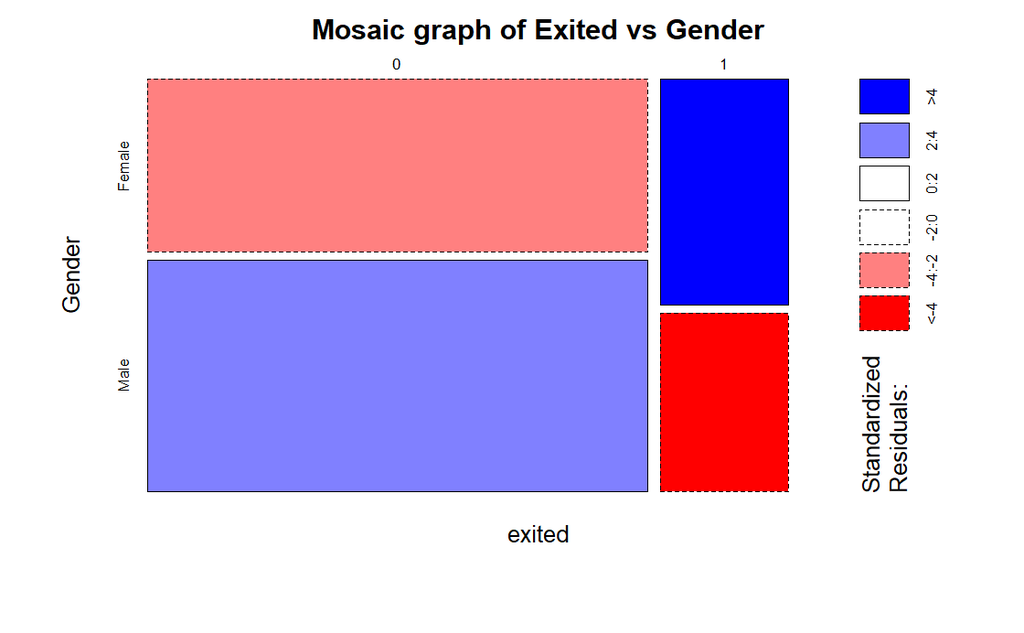

```r
mytable2 <- table(Exited, Gender)
mosaicplot(mytable2, ylab= "Gender", xlab="exited", main = "Mosaic graph of Exited vs Gender", shade=TRUE)
```

```r
chisq.test(mytable2)
```

```
    Pearson's Chi-squared test with Yates' continuity correction

data:  mytable2
X-squared = 112.92, df = 1, p-value < 2.2e-16
```

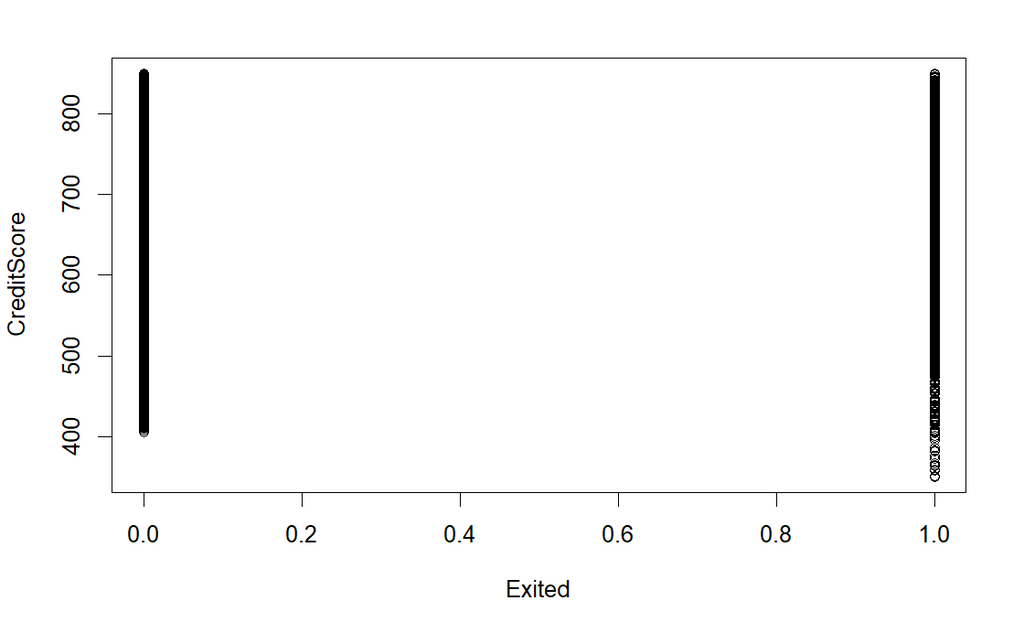

```r
plot(CreditScore~Exited)
```

```r
t.test(CreditScore~Exited, alternative="two.sided")
```

```
    Welch Two Sample t-test

data:  CreditScore by Exited
t = 2.6347, df = 3050.9, p-value = 0.008465
alternative hypothesis: true difference in means between group 0 and group 1 is not equal to 0
95 percent confidence interval:
  1.663067 11.340331
sample estimates:
mean in group 0 mean in group 1
       651.8532        645.3515
```

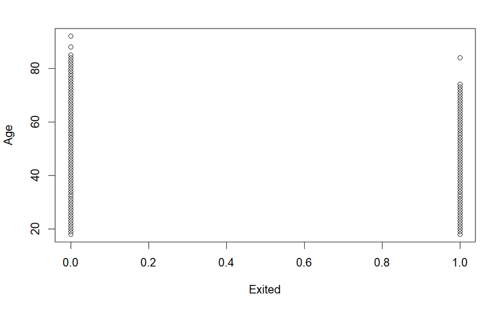

```r
plot(Age~Exited)
```

```r
t.test(Age~Exited, alternative="two.sided")
```

```
    Welch Two Sample t-test

data:  Age by Exited
t = -30.419, df = 3248.1, p-value < 2.2e-16
alternative hypothesis: true difference in means between group 0 and group 1 is not equal to 0
95 percent confidence interval:
 -7.908490 -6.950727
sample estimates:
mean in group 0 mean in group 1
       37.40839        44.83800
```

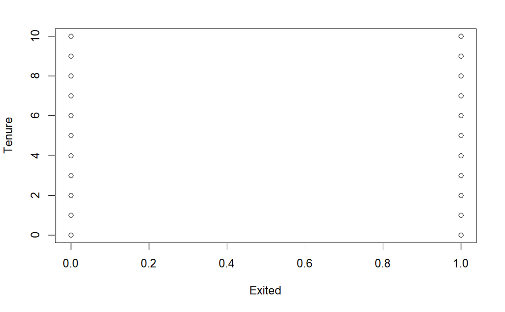

```r
plot(Tenure~Exited)
```

```r
t.test(Tenure~Exited, alternative="two.sided")
```

```
    Welch Two Sample t-test

data:  Tenure by Exited
t = 1.3843, df = 3113.8, p-value = 0.1664
alternative hypothesis: true difference in means between group 0 and group 1 is not equal to 0
95 percent confidence interval:
 -0.04185994  0.24292931
sample estimates:
mean in group 0 mean in group 1
       5.033279        4.932744
```

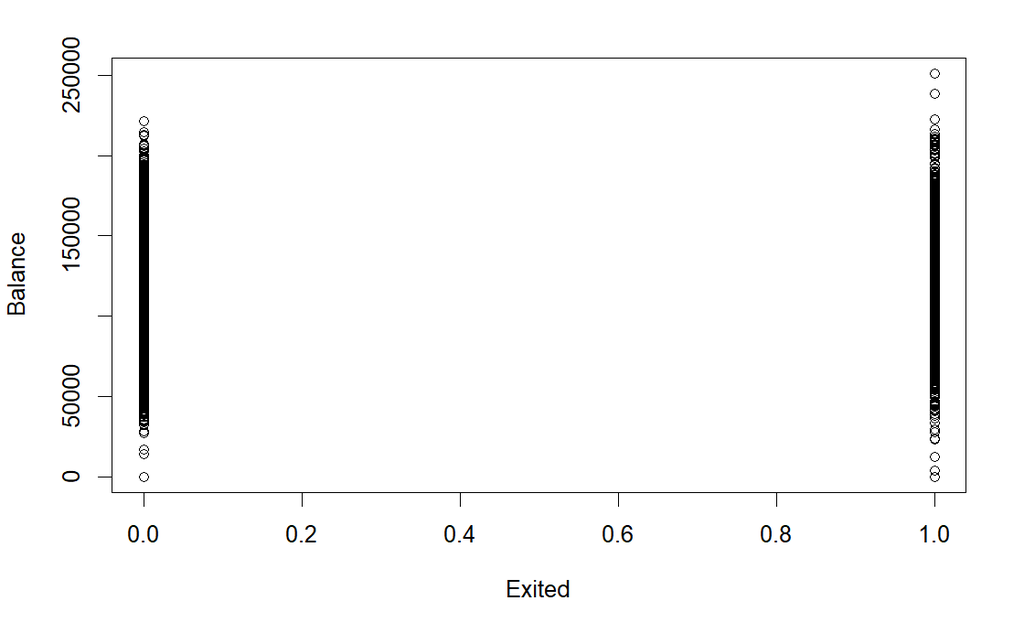

```r
plot(Balance~Exited)
```

```r
t.test(Balance~Exited, alternative="two.sided")
```

```
    Welch Two Sample t-test

data:  Balance by Exited
t = -12.471, df = 3347.8, p-value < 2.2e-16
alternative hypothesis: true difference in means between group 0 and group 1 is not equal to 0
95 percent confidence interval:
 -21250.22 -15476.26
sample estimates:
mean in group 0 mean in group 1
       72745.30        91108.54
```

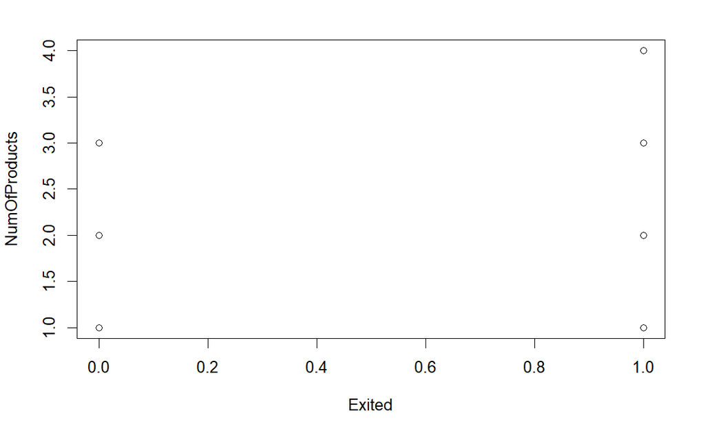

```r
plot(NumOfProducts~Exited)
```

```r
t.test(NumOfProducts~Exited, alternative="two.sided")
```

```
    Welch Two Sample t-test

data:  NumOfProducts by Exited
t = 3.702, df = 2472, p-value = 0.0002186
alternative hypothesis: true difference in means between group 0 and group 1 is not equal to 0
95 percent confidence interval:
 0.03247871 0.10563848
sample estimates:
mean in group 0 mean in group 1
       1.544267        1.475209
```

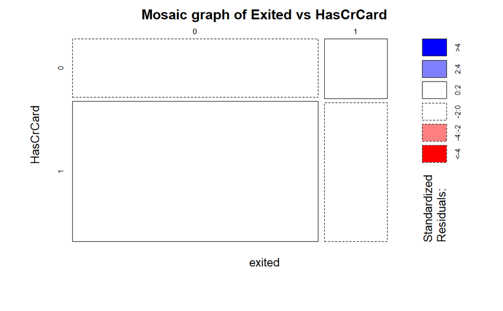

```r
mytable3 <- table(Exited, HasCrCard)
mosaicplot(mytable3, ylab= "HasCrCard", xlab="exited", main = "Mosaic graph of Exited vs HasCrCard", shade=TRUE)
```

```r
chisq.test(mytable3)
```

```
    Pearson's Chi-squared test with Yates' continuity correction

data:  mytable3
X-squared = 0.47134, df = 1, p-value = 0.4924
```

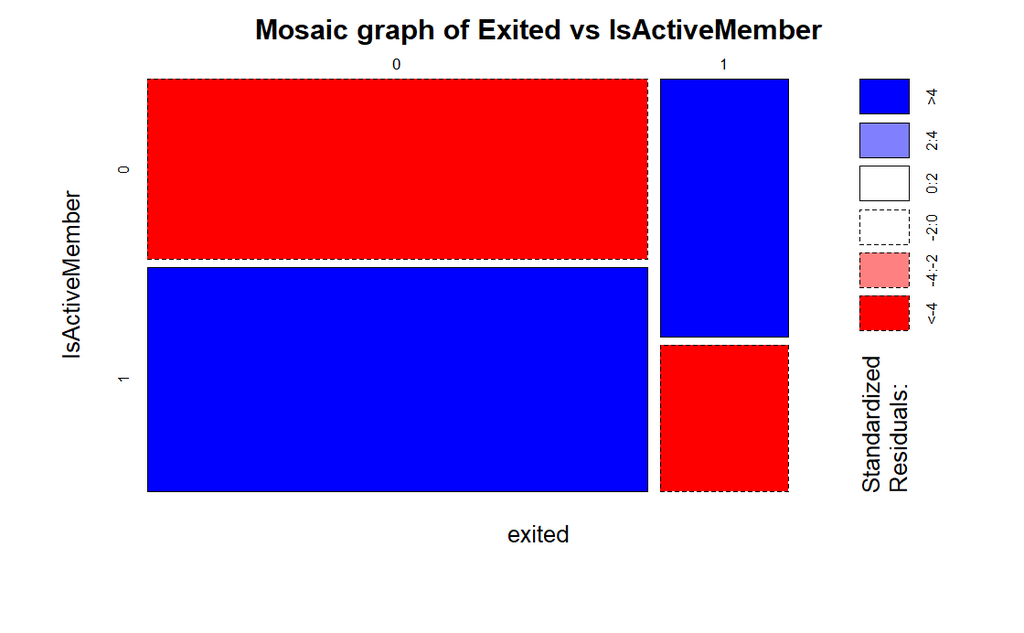

```r
mytable4 <- table(Exited, IsActiveMember)
mosaicplot(mytable4, ylab= "IsActiveMember", xlab="exited", main = "Mosaic graph of Exited vs IsActiveMember", shade=TRUE)
```

```r
chisq.test(mytable4)
```

```
    Pearson's Chi-squared test with Yates' continuity correction

data:  mytable4
X-squared = 242.99, df = 1, p-value < 2.2e-16
```

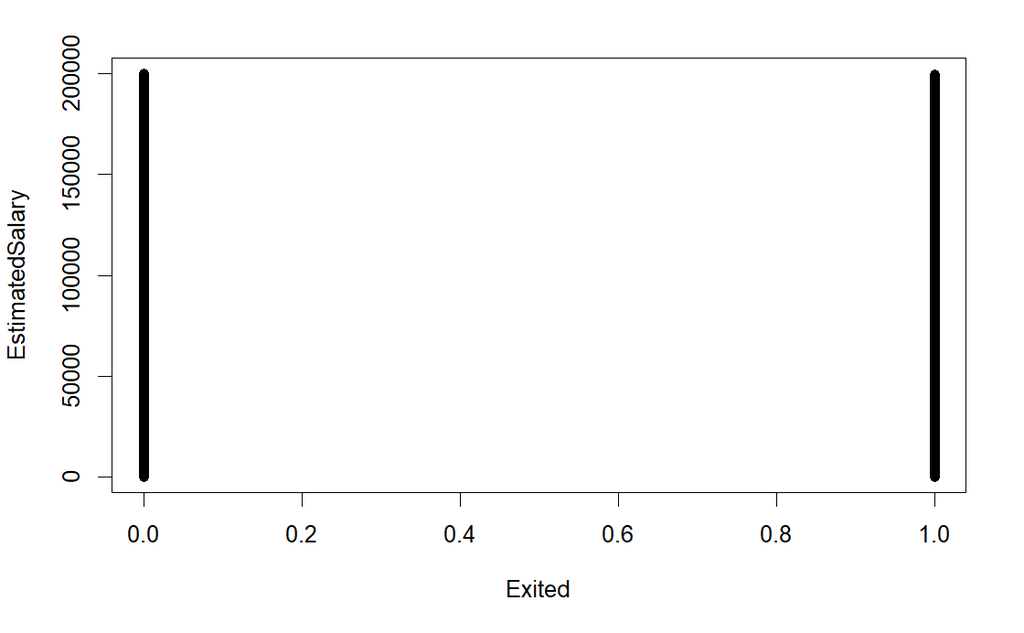

```r
plot(EstimatedSalary~Exited)
```

```r
t.test(EstimatedSalary~Exited, alternative="two.sided")
```

```
    Welch Two Sample t-test

data:  EstimatedSalary by Exited
t = -1.2034, df = 3137.4, p-value = 0.2289
alternative hypothesis: true difference in means between group 0 and group 1 is not equal to 0
95 percent confidence interval:
 -4541.656  1087.085
sample estimates:
mean in group 0 mean in group 1
       99738.39       101465.68
```

ans: geography, gender, CreditScore, Age, Balance, NumOfProducts, IsActiveMember are associated with “Exited”

removing variables not associated with Exited

```r
cm <- cm[-c(5,8,10)]
str(cm)
```

```
'data.frame':   10000 obs. of  8 variables:
 $ CreditScore   : int  619 608 502 699 850 645 822 376 501 684 ...
 $ Geography     : Factor w/ 3 levels "France","Germany",..: 1 3 1 1 3 3 1 2 1 1 ...
 $ Gender        : Factor w/ 2 levels "Female","Male": 1 1 1 1 1 2 2 1 2 2 ...
 $ Age           : int  42 41 42 39 43 44 50 29 44 27 ...
 $ Balance       : num  0 83808 159661 0 125511 ...
 $ NumOfProducts : int  1 1 3 2 1 2 2 4 2 1 ...
 $ IsActiveMember: int  1 1 0 0 1 0 1 0 1 1 ...
 $ Exited        : int  1 0 1 0 0 1 0 1 0 0 ...
```

3)Set the random seed, set.seed(123), and split the data to train/test. Use 80% of samples for training and the remaining 20% for testing

```r
library(caret)
set.seed(123)
train_indices1= createDataPartition(Exited, p=0.8, list=FALSE)
cm_train= cm[train_indices1,]
cm_test=cm[-train_indices1,]
str(cm_train)
```

```
'data.frame':   8000 obs. of  8 variables:
 $ CreditScore   : int  619 608 502 699 850 822 376 501 684 528 ...
 $ Geography     : Factor w/ 3 levels "France","Germany",..: 1 3 1 1 3 1 2 1 1 1 ...
 $ Gender        : Factor w/ 2 levels "Female","Male": 1 1 1 1 1 2 1 2 2 2 ...
 $ Age           : int  42 41 42 39 43 50 29 44 27 31 ...
 $ Balance       : num  0 83808 159661 0 125511 ...
 $ NumOfProducts : int  1 1 3 2 1 2 4 2 1 2 ...
 $ IsActiveMember: int  1 1 0 0 1 1 0 1 1 0 ...
 $ Exited        : int  1 0 1 0 0 0 1 0 0 0 ...
```

```r
str(cm_test)
```

```
'data.frame':   2000 obs. of  8 variables:
 $ CreditScore   : int  645 587 510 520 722 804 582 465 556 834 ...
 $ Geography     : Factor w/ 3 levels "France","Germany",..: 3 3 3 3 3 3 2 1 1 1 ...
 $ Gender        : Factor w/ 2 levels "Female","Male": 2 2 1 1 1 2 2 1 1 1 ...
 $ Age           : int  44 45 38 42 29 33 41 51 61 49 ...
 $ Balance       : num  113756 0 0 0 0 ...
 $ NumOfProducts : int  2 1 1 2 2 1 2 1 1 1 ...
 $ IsActiveMember: int  0 0 0 1 1 1 1 0 1 0 ...
 $ Exited        : int  1 0 1 0 0 0 0 1 0 1 ...
```

4)Train a logistic regression model on the train data using the glm package and use it to predict “Exited” for the test data.

```r
cm_train$Exited=factor(cm_train$Exited)
logistic_model= glm(Exited~., data = cm_train, family = "binomial")
summary(logistic_model)
```

```
Call:
glm(formula = Exited ~ ., family = "binomial", data = cm_train)

Deviance Residuals:
    Min       1Q   Median       3Q      Max
-2.3627  -0.6557  -0.4534  -0.2664   2.9875

Coefficients:
                   Estimate Std. Error z value Pr(>|z|)
(Intercept)      -3.474e+00  2.598e-01 -13.371  < 2e-16 ***
CreditScore      -6.839e-04  3.136e-04  -2.181   0.0292 *
GeographyGermany  7.868e-01  7.581e-02  10.378  < 2e-16 ***
GeographySpain    4.015e-02  7.879e-02   0.510   0.6103
GenderMale       -5.512e-01  6.094e-02  -9.045  < 2e-16 ***
Age               7.400e-02  2.904e-03  25.482  < 2e-16 ***
Balance           2.602e-06  5.733e-07   4.540 5.64e-06 ***
NumOfProducts    -1.053e-01  5.282e-02  -1.993   0.0463 *
IsActiveMember   -1.087e+00  6.463e-02 -16.815  < 2e-16 ***
---
Signif. codes:  0 ‘***’ 0.001 ‘**’ 0.01 ‘*’ 0.05 ‘.’ 0.1 ‘ ’ 1

(Dispersion parameter for binomial family taken to be 1)

    Null deviance: 8099.8  on 7999  degrees of freedom
Residual deviance: 6839.1  on 7991  degrees of freedom
AIC: 6857.1

Number of Fisher Scoring iterations: 5
```

```r
predictions= predict(logistic_model, cm_test, type="response")
head(predictions)
```

```
         6         19         23         34         35         38
0.25275489 0.23847403 0.25440165 0.12151015 0.04400648 0.04372367
```

5)the cross table between the predicted labels and true labels in the test data and compute total_error, false positive rate, and false negative rate.

```r
predicted.label = factor(ifelse(predictions>0.5, 1,0))
actual.label= cm_test$Exited
t=table(predicted.label, actual.label)
t
```

```
               actual.label
predicted.label    0    1
              0 1529  316
              1   68   87
```

```r
error=t(t[1,2]+t[2,1])/sum(t)
error
```

```
      [,1]
[1,] 0.192
```

```r
FPR = t[1,2]/(t[1,2]+t[1,1])
FNR = t[2,1]/(t[2,1]+t[2,2])
FPR
```

```
[1] 0.1712737
```

```r
FNR
```

```
[1] 0.4387097
```

error= 0.192 FPR= 0.1712737 FNR= 0.4387097

6)down sampling

```r
cm_train1= cm_train[cm_train$Exited==0,]
cm_train1
```

|  | CreditScore | Geography | Gender | Age | Balance | NumOfProducts | IsActiveMember | Exited |
| --- | --- | --- | --- | --- | --- | --- | --- | --- |
| 2 | 608 | Spain | Female | 41 | 83807.86 | 1 | 1 | 0 |
| 4 | 699 | France | Female | 39 | 0.00 | 2 | 0 | 0 |
| 5 | 850 | Spain | Female | 43 | 125510.82 | 1 | 1 | 0 |
| 7 | 822 | France | Male | 50 | 0.00 | 2 | 1 | 0 |
| 9 | 501 | France | Male | 44 | 142051.07 | 2 | 1 | 0 |
| 10 | 684 | France | Male | 27 | 134603.88 | 1 | 1 | 0 |
| 11 | 528 | France | Male | 31 | 102016.72 | 2 | 0 | 0 |
| 12 | 497 | Spain | Male | 24 | 0.00 | 2 | 0 | 0 |
| 13 | 476 | France | Female | 34 | 0.00 | 2 | 0 | 0 |
| 14 | 549 | France | Female | 25 | 0.00 | 2 | 0 | 0 |

[output cut: 990 more lines]

```r
cm_train2= cm_train[cm_train$Exited==1,]
cm_train2
```

|  | CreditScore | Geography | Gender | Age | Balance | NumOfProducts | IsActiveMember | Exited |
| --- | --- | --- | --- | --- | --- | --- | --- | --- |
| 1 | 619 | France | Female | 42 | 0.00 | 1 | 1 | 1 |
| 3 | 502 | France | Female | 42 | 159660.80 | 3 | 0 | 1 |
| 8 | 376 | Germany | Female | 29 | 115046.74 | 4 | 0 | 1 |
| 17 | 653 | Germany | Male | 58 | 132602.88 | 1 | 0 | 1 |
| 31 | 591 | Spain | Female | 39 | 0.00 | 3 | 0 | 1 |
| 36 | 475 | France | Female | 45 | 134264.04 | 1 | 0 | 1 |
| 47 | 829 | Germany | Female | 27 | 112045.67 | 1 | 1 | 1 |
| 54 | 655 | Germany | Male | 41 | 125561.97 | 1 | 0 | 1 |
| 55 | 601 | Germany | Male | 42 | 98495.72 | 1 | 0 | 1 |
| 59 | 511 | Spain | Female | 66 | 0.00 | 1 | 0 | 1 |

[output cut: 990 more lines]

```r
train_sample<-sample(6366, 1634)
cm_train3<-cm_train1[train_sample,]
cm_train3
```

|  | CreditScore | Geography | Gender | Age | Balance | NumOfProducts | IsActiveMember | Exited |
| --- | --- | --- | --- | --- | --- | --- | --- | --- |
| 3183 | 669 | France | Female | 43 | 160474.59 | 1 | 1 | 0 |
| 3933 | 680 | France | Male | 23 | 140007.19 | 1 | 1 | 0 |
| 4246 | 732 | France | Female | 34 | 122338.43 | 2 | 0 | 0 |
| 1947 | 648 | Germany | Male | 34 | 95039.73 | 2 | 1 | 0 |
| 9827 | 789 | Spain | Female | 40 | 0.00 | 2 | 0 | 0 |
| 3558 | 675 | France | Male | 34 | 124619.33 | 2 | 1 | 0 |
| 1417 | 585 | Spain | Female | 33 | 0.00 | 2 | 0 | 0 |
| 8062 | 477 | Spain | Male | 31 | 0.00 | 2 | 1 | 0 |
| 9695 | 581 | France | Male | 25 | 77886.53 | 2 | 0 | 0 |
| 577 | 439 | Spain | Female | 32 | 138901.61 | 1 | 0 | 0 |

[output cut: 990 more lines]

```r
cm_train4<-rbind(cm_train3, cm_train2)
cm_train4
```

|  | CreditScore | Geography | Gender | Age | Balance | NumOfProducts | IsActiveMember | Exited |
| --- | --- | --- | --- | --- | --- | --- | --- | --- |
| 3183 | 669 | France | Female | 43 | 160474.59 | 1 | 1 | 0 |
| 3933 | 680 | France | Male | 23 | 140007.19 | 1 | 1 | 0 |
| 4246 | 732 | France | Female | 34 | 122338.43 | 2 | 0 | 0 |
| 1947 | 648 | Germany | Male | 34 | 95039.73 | 2 | 1 | 0 |
| 9827 | 789 | Spain | Female | 40 | 0.00 | 2 | 0 | 0 |
| 3558 | 675 | France | Male | 34 | 124619.33 | 2 | 1 | 0 |
| 1417 | 585 | Spain | Female | 33 | 0.00 | 2 | 0 | 0 |
| 8062 | 477 | Spain | Male | 31 | 0.00 | 2 | 1 | 0 |
| 9695 | 581 | France | Male | 25 | 77886.53 | 2 | 0 | 0 |
| 577 | 439 | Spain | Female | 32 | 138901.61 | 1 | 0 | 0 |

[output cut: 990 more lines]

```r
logistic_model1= glm(Exited~., data = cm_train4, family = "binomial")
summary(logistic_model1)
```

```
Call:
glm(formula = Exited ~ ., family = "binomial", data = cm_train4)

Deviance Residuals:
     Min        1Q    Median        3Q       Max
-2.97711  -0.93230  -0.03654   0.93143   2.60079

Coefficients:
                   Estimate Std. Error z value Pr(>|z|)
(Intercept)      -2.573e+00  3.374e-01  -7.624 2.45e-14 ***
CreditScore      -7.925e-04  4.073e-04  -1.946   0.0517 .
GeographyGermany  7.166e-01  1.008e-01   7.108 1.18e-12 ***
GeographySpain    7.683e-02  1.012e-01   0.759   0.4476
GenderMale       -6.180e-01  7.994e-02  -7.731 1.07e-14 ***
Age               8.382e-02  4.309e-03  19.452  < 2e-16 ***
Balance           3.724e-06  7.266e-07   5.124 2.99e-07 ***
NumOfProducts    -6.773e-02  6.070e-02  -1.116   0.2645
IsActiveMember   -9.961e-01  8.131e-02 -12.250  < 2e-16 ***
---
Signif. codes:  0 ‘***’ 0.001 ‘**’ 0.01 ‘*’ 0.05 ‘.’ 0.1 ‘ ’ 1

(Dispersion parameter for binomial family taken to be 1)

    Null deviance: 4530.4  on 3267  degrees of freedom
Residual deviance: 3707.9  on 3259  degrees of freedom
AIC: 3725.9

Number of Fisher Scoring iterations: 4
```

```r
predictions1= predict(logistic_model1, cm_test, type="response")
head(predictions1)
```

```
        6        19        23        34        35        38
0.5869599 0.5313009 0.5541808 0.3731182 0.1457087 0.1463465
```

```r
predicted.label1 = factor(ifelse(predictions1>0.5, 1,0))
actual.label1= cm_test$Exited
t1=table(predicted.label1, actual.label1)
t1
```

```
                actual.label1
predicted.label1    0    1
               0 1114  123
               1  483  280
```

```r
error1=t(t1[1,2]+t1[2,1])/sum(t1)
error1
```

```
      [,1]
[1,] 0.303
```

```r
FPR1 = t1[1,2]/(t1[1,2]+t1[1,1])
FNR1 = t1[2,1]/(t1[2,1]+t1[2,2])
FPR1
```

```
[1] 0.09943411
```

```r
FNR1
```

```
[1] 0.6330275
```

7)Repeating steps 4,5,6 above by using a C5.0 decision tree model to predict “Exited”. Compare the logistic regression model with the boosted C5.0 model.

```r
library(C50)
cm_train$Exited=factor(cm_train$Exited)
cmc50 <-C5.0(cm_train[-8], cm_train$Exited, trials = 30)
cmc50
```

```
Call:
C5.0.default(x = cm_train[-8], y = cm_train$Exited, trials = 30)

Classification Tree
Number of samples: 8000
Number of predictors: 7

Number of boosting iterations: 30
Average tree size: 16.2

Non-standard options: attempt to group attributes
```

```r
library(gmodels)
cm_pred10 <-predict(cmc50, cm_test)
tab=CrossTable(cm_test$Exited, cm_pred10, prop.chisq= FALSE, prop.c= FALSE, prop.r= FALSE, dnn= c('actual default', 'predicted default'))
```

```
   Cell Contents
|-------------------------|
|                       N |
|         N / Table Total |
|-------------------------|


Total Observations in Table:  2000


               | predicted default
actual default |         0 |         1 | Row Total |
---------------|-----------|-----------|-----------|
             0 |      1533 |        64 |      1597 |
               |     0.766 |     0.032 |           |
---------------|-----------|-----------|-----------|
             1 |       198 |       205 |       403 |
               |     0.099 |     0.102 |           |
---------------|-----------|-----------|-----------|
  Column Total |      1731 |       269 |      2000 |
---------------|-----------|-----------|-----------|
```

```r
tab
```

```
$t
   y
x      0    1
  0 1533   64
  1  198  205

$prop.row
   y
x            0          1
  0 0.95992486 0.04007514
  1 0.49131514 0.50868486

$prop.col
   y
x           0         1
  0 0.8856153 0.2379182
  1 0.1143847 0.7620818

$prop.tbl
   y
x        0      1
  0 0.7665 0.0320
  1 0.0990 0.1025
```

```r
error1=(64+198)/2000
error1
```

```
[1] 0.131
```

```r
FPR2 = 64/(1533+64)
FNR2 = 198/(198+205)
FPR2
```

```
[1] 0.04007514
```

```r
FNR2
```

```
[1] 0.4913151
```

error= 0.131 FPR= 0.04007514 FNR= 0.4913151

```r
cm_train4$Exited=factor(cm_train4$Exited)
cmc501 <-C5.0(cm_train4[-8], cm_train4$Exited, trials = 30)
cmc501
```

```
Call:
C5.0.default(x = cm_train4[-8], y = cm_train4$Exited, trials = 30)

Classification Tree
Number of samples: 3268
Number of predictors: 7

Number of boosting iterations: 30 requested;  15 used due to early stopping
Average tree size: 16.3

Non-standard options: attempt to group attributes
```

```r
cm_pred101 <-predict(cmc501, cm_test)
tab1=CrossTable(cm_test$Exited, cm_pred101, prop.chisq= FALSE, prop.c= FALSE, prop.r= FALSE, dnn= c('actual default', 'predicted default'))
```

```
   Cell Contents
|-------------------------|
|                       N |
|         N / Table Total |
|-------------------------|


Total Observations in Table:  2000


               | predicted default
actual default |         0 |         1 | Row Total |
---------------|-----------|-----------|-----------|
             0 |      1269 |       328 |      1597 |
               |     0.634 |     0.164 |           |
---------------|-----------|-----------|-----------|
             1 |       104 |       299 |       403 |
               |     0.052 |     0.149 |           |
---------------|-----------|-----------|-----------|
  Column Total |      1373 |       627 |      2000 |
---------------|-----------|-----------|-----------|
```

```r
tab1
```

```
$t
   y
x      0    1
  0 1269  328
  1  104  299

$prop.row
   y
x           0         1
  0 0.7946149 0.2053851
  1 0.2580645 0.7419355

$prop.col
   y
x            0          1
  0 0.92425346 0.52312600
  1 0.07574654 0.47687400

$prop.tbl
   y
x        0      1
  0 0.6345 0.1640
  1 0.0520 0.1495
```

```r
error1=(328+104)/2000
error1
```

```
[1] 0.216
```

```r
FPR2 = 328/(1269+328)
FNR2 = 104/(104+299)
FPR2
```

```
[1] 0.2053851
```

```r
FNR2
```

```
[1] 0.2580645
```

ans: The total error given by the boosted C5.0 model- 13.1% The total error given by the logistic regression model before down sampling - 19.2% I think the boosted C5.0 model does better than the logistic regression model.